# Climax community

Cassandra Wattenburger

4/13/2022

```r
# Clear working directory, load in packages, generate package info
rm(list=ls())

library("phyloseq")
library("vegan")
library("tidyverse")
library("lmerTest")
```

# Import data

- metadata
- growth estimates
- normalized abundances
- rarefied phyloseq

```r
# Metadata
meta <- readRDS("../data_intermediate/SFA2_metadata.rds")

# Growth estimates
growth <- readRDS("../data_intermediate/SFA2_growth_estimates_pap.rds")

# Death estimates
death <- readRDS("../data_intermediate/SFA2_death_estimates_pap.rds")

# Normalized abundance data
norm <- readRDS("../data_intermediate/SFA2_normalized.rds")

# Rarefied phyloseq
physeq <- readRDS("../data_intermediate/SFA2_physeq_rare.rds")
```

# Idenitfy pre and post level off

Defining as when the total normalized abundance of each inoculant evens out, indicating balanced growth and death.

### Total normalized abundances

Whole communities:

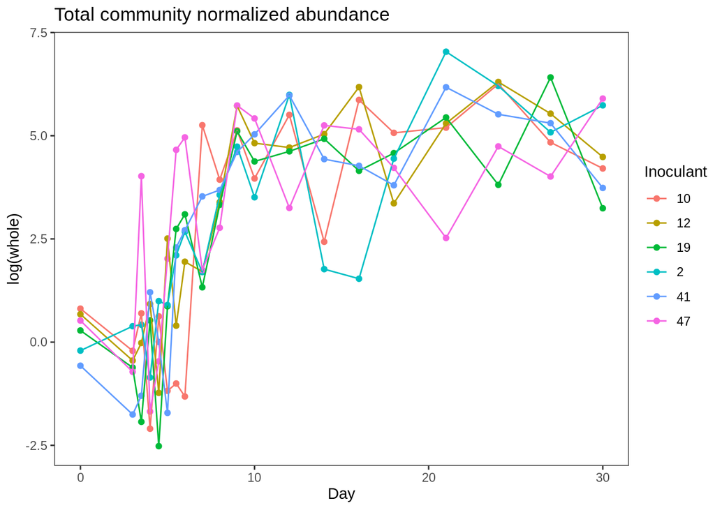

```r
# Add metadata and reformat
meta <- meta %>%
  select(SampleID, Sample, Inoculant, Day, Replicate)

norm_meta <- norm %>%
  full_join(meta)

# Calculate total normalized abundance through time
norm_total <- norm_meta %>%
  group_by(Inoculant, Day, ASV) %>%
  summarize(norm_abund_avg = mean(norm_abund, na.rm=TRUE)) %>% # average across reps
  ungroup() %>%
  group_by(Inoculant, Day) %>%
  summarize(whole = sum(norm_abund_avg, na.rm=TRUE)) %>% # calc total abund
  ungroup()

# Visualize
norm_total %>%
  filter(Inoculant %in% c(10, 12,19, 2, 41,47)) %>%
  ggplot(aes(x=Day, y=log(whole), color=Inoculant)) +
  geom_point() +
  geom_line() +
  labs(title="Total community normalized abundance") +
  theme_test()
```

Growers only:

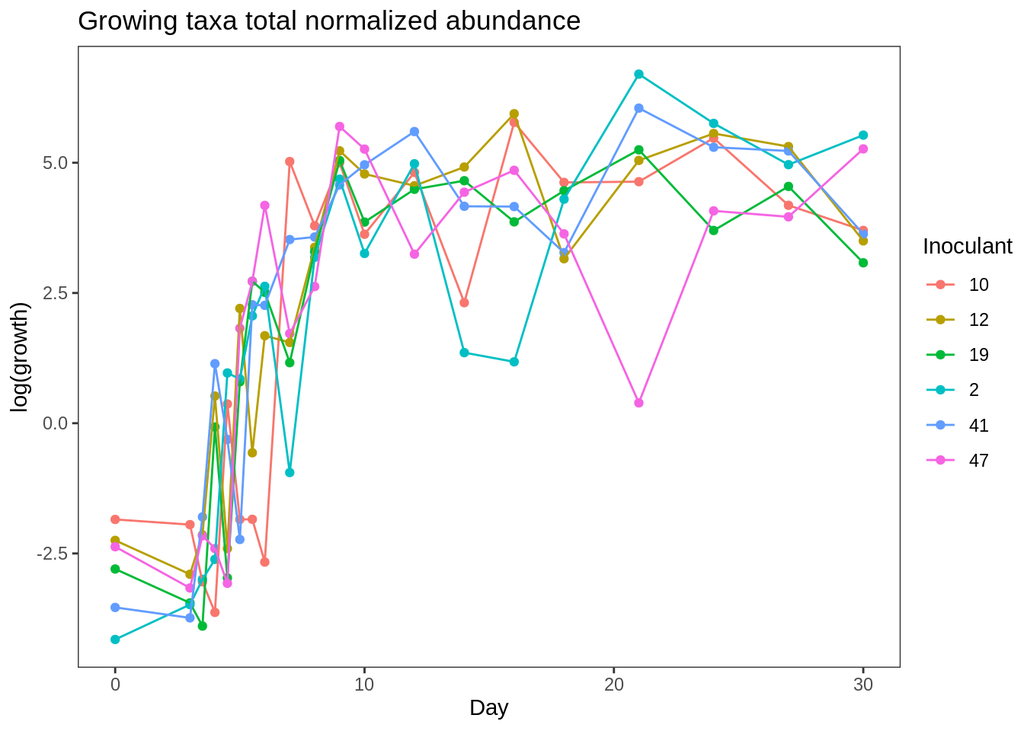

```r
# Make a label
growth_labels <- growth %>%
  mutate(label = paste0(Inoculant, ASV)) %>%
  select(label)

# Calculate total normalized abundance through time
norm_total_gr <- norm_meta %>%
  mutate(label = paste0(Inoculant, ASV)) %>%
  inner_join(growth_labels) %>% # isolate growing taxa only
  group_by(Inoculant, Day, ASV) %>% # average across replicates
  summarize(norm_abund_avg = mean(norm_abund, na.rm=TRUE)) %>%
  ungroup() %>%
  group_by(Inoculant, Day) %>% # total normalized abundance
  summarize(growth = sum(norm_abund_avg, na.rm=TRUE)) %>%
  ungroup()

# Visualize
norm_total_gr %>%
  ggplot(aes(x=Day, y=log(growth), color=Inoculant)) +
  geom_point() +
  geom_line() +
  labs(title="Growing taxa total normalized abundance") +
  theme_test()
```

Together:

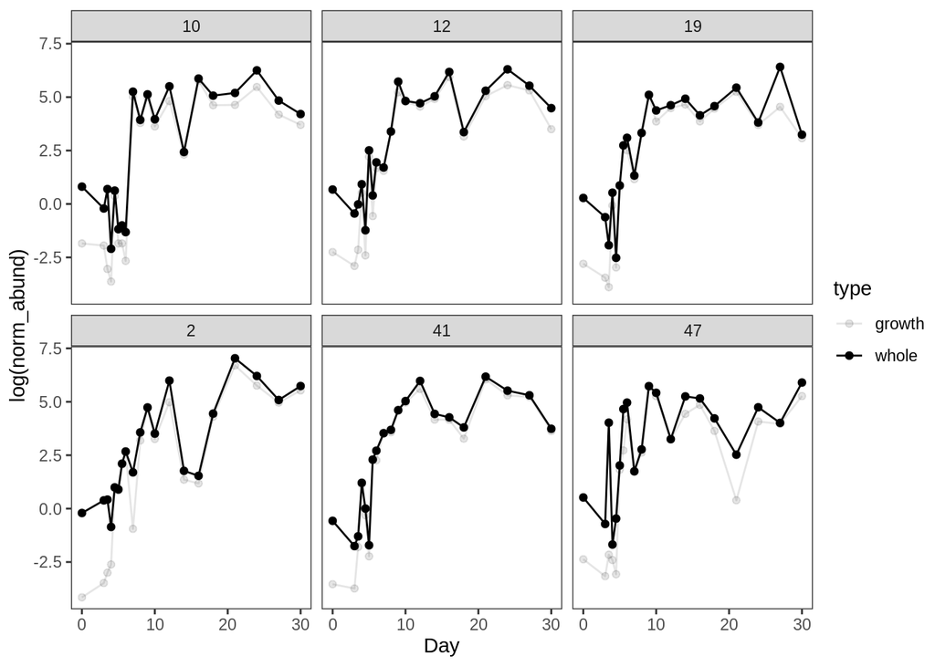

```r
# Combine whole community and growing community normalized abundance totals
norm_total_all <- norm_total %>%
  inner_join(norm_total_gr) %>%
  pivot_longer(-c(Inoculant, Day), names_to="type", values_to="norm_abund")

# Visualize
norm_total_all %>%
  ggplot(aes(x=Day, y=log(norm_abund), alpha=type)) +
  geom_point() +
  geom_line() +
  facet_wrap(~Inoculant) +
  theme_test()
```

Most abundance is made up of taxa with growth estimates after day 3 or 4, indicating we did a pretty good job of capturing the growers/major players in the bottles.

Average total abundance across inoculants:

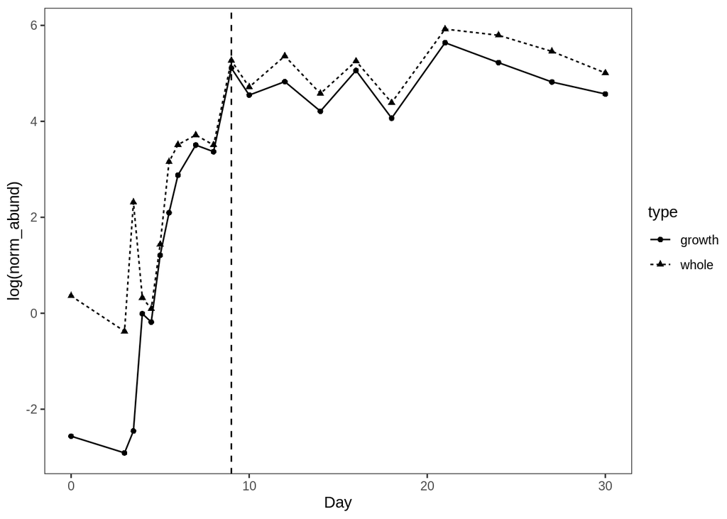

```r
norm_total_all %>%
  group_by(Day, type) %>%
  summarize(norm_abund = mean(norm_abund, na.rm=TRUE)) %>%
  ungroup() %>%
  #filter(type=="whole") %>%
  ggplot(aes(x=Day, y=log(norm_abund))) +
  geom_point(aes(shape=type)) +
  #geom_line() +
  geom_line(aes(linetype=type)) +
  geom_vline(xintercept = 9, linetype=2) +
  #labs(y="log normalized abundance of whole community") +
  theme_test()
```

Day 9 seems to be where the total abundances start to “even out”. We’ll define this until the end of the incubation as the plateau community.

### Isolate pre and post

- count data
- growth estimates by start day

```r
# Phyloseq object
meta_lvloff <- mutate(meta, leveloff = if_else(Day <= 9, "exponential", "steady"))
physeq_lvloff <- phyloseq(otu_table(physeq), tax_table(physeq), physeq@phy_tree, sample_data(meta_lvloff))

# Growth start day
growth_prepost <- growth %>%
  mutate(startend = if_else(start_day <= 9 & end_day <= 9, "exp-exp",
                            if_else(start_day <= 9 & end_day > 9, "exp-steady", "steady-steady")),
         startend = fct_relevel(startend, c("exp-exp", "exp-steady", "steady-steady")))

# Death start day
death_prepost <- death %>%
  mutate(startend = if_else(start_day <= 9 & end_day <= 9, "exp-exp",
                            if_else(start_day <= 9 & end_day > 9, "exp-steady", "steady-steady")),
         startend = fct_relevel(startend, c("exp-exp", "exp-steady", "steady-steady")))
```

Growth summary:

```r
growth_prepost_summary <-  growth_prepost %>%
  group_by(Inoculant, startend) %>%
  summarize(num = n())

growth_prepost_summary %>%
  group_by(startend) %>%
  summarize(num_mean = mean(num), num_sd = sd(num))
```

```
## # A tibble: 3 × 3
##   startend      num_mean num_sd
##   <fct>            <dbl>  <dbl>
## 1 exp-exp            5.5  3.39
## 2 exp-steady        20.8  8.77
## 3 steady-steady      1.5  0.577
```

Death summary:

```r
death_prepost_summary <-  death_prepost %>%
  group_by(Inoculant, startend) %>%
  summarize(num = n())

death_prepost_summary %>%
  group_by(startend) %>%
  summarize(num_mean = mean(num), num_sd = sd(num))
```

```
## # A tibble: 3 × 3
##   startend      num_mean num_sd
##   <fct>            <dbl>  <dbl>
## 1 exp-exp           12.8   9.54
## 2 exp-steady         3     1.58
## 3 steady-steady      3     0
```

# Growth

### Growth traits

- growth rates
- change in abundance

Visualize:

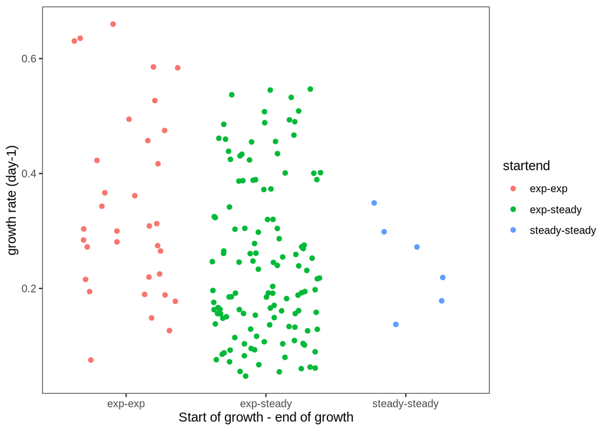

```r
# k
growth_prepost %>%
  ggplot(aes(x=startend, y=k, color=startend)) +
  geom_jitter() +
  theme_test() +
  labs(y="growth rate (day-1)", x="Start of growth - end of growth")
```

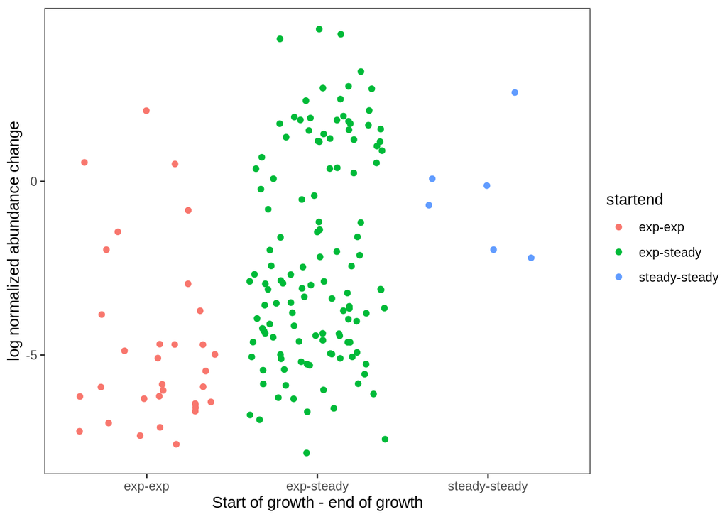

```r
# change in abundance
growth_prepost %>%
  ggplot(aes(x=startend, y=log(change_abund), color=startend)) +
  geom_jitter() +
  theme_test() +
  labs(y="log normalized abundance change", x="Start of growth - end of growth")
```

Linear mixed effects models with random slopes and intercepts for inoculant

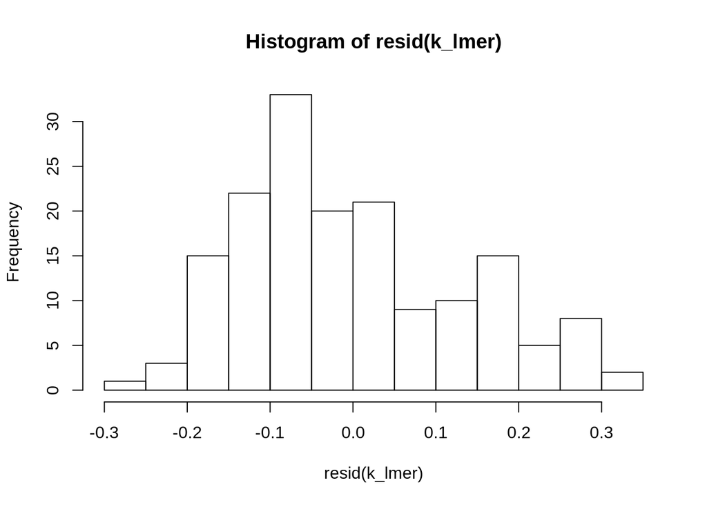

```r
# k
k_lmer <- lmer(k ~ startend + (1 + Inoculant | Inoculant), growth_prepost)
hist(resid(k_lmer))
```

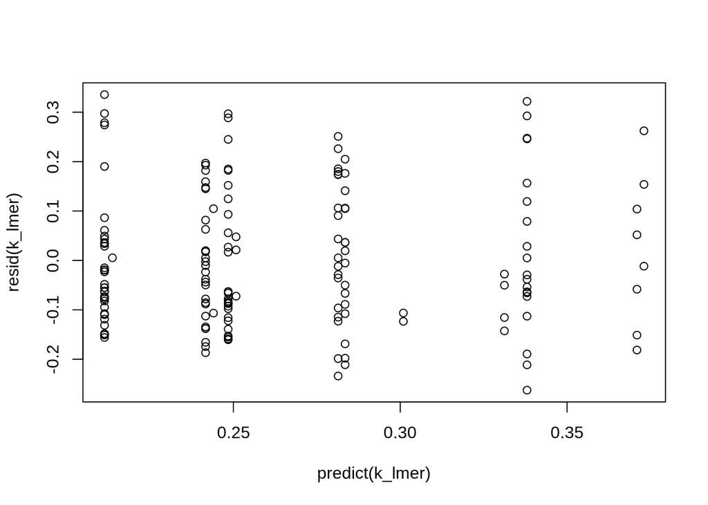

```r
plot(predict(k_lmer), resid(k_lmer))
```

```r
anova(k_lmer)
```

```
## Type III Analysis of Variance Table with Satterthwaite's method
##           Sum Sq Mean Sq NumDF DenDF F value   Pr(>F)
## startend 0.20217 0.10108     2 144.5  5.3545 0.005711 **
## ---
## Signif. codes:  0 '***' 0.001 '**' 0.01 '*' 0.05 '.' 0.1 ' ' 1
```

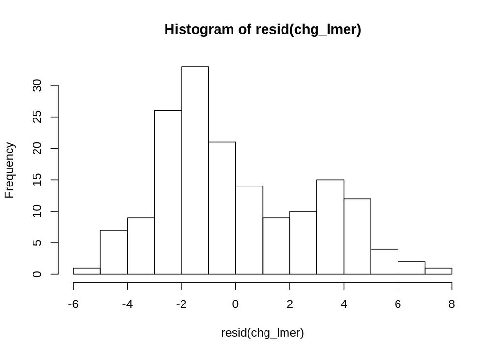

```r
# change abund
chg_lmer <- lmer(log(change_abund) ~ startend + (1 + Inoculant | Inoculant), growth_prepost)
hist(resid(chg_lmer))
```

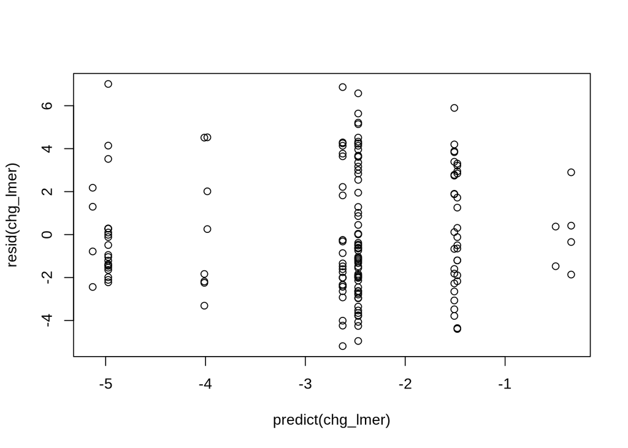

```r
plot(predict(chg_lmer), resid(chg_lmer))
```

```r
anova(chg_lmer)
```

```
## Type III Analysis of Variance Table with Satterthwaite's method
##          Sum Sq Mean Sq NumDF  DenDF F value    Pr(>F)
## startend 203.42  101.71     2 159.36   12.72 7.497e-06 ***
## ---
## Signif. codes:  0 '***' 0.001 '**' 0.01 '*' 0.05 '.' 0.1 ' ' 1
```

### Growth correlations

Teasing apart relationship between category and growth traits, is it due to length of growth?

Length of growth vs growth rates:

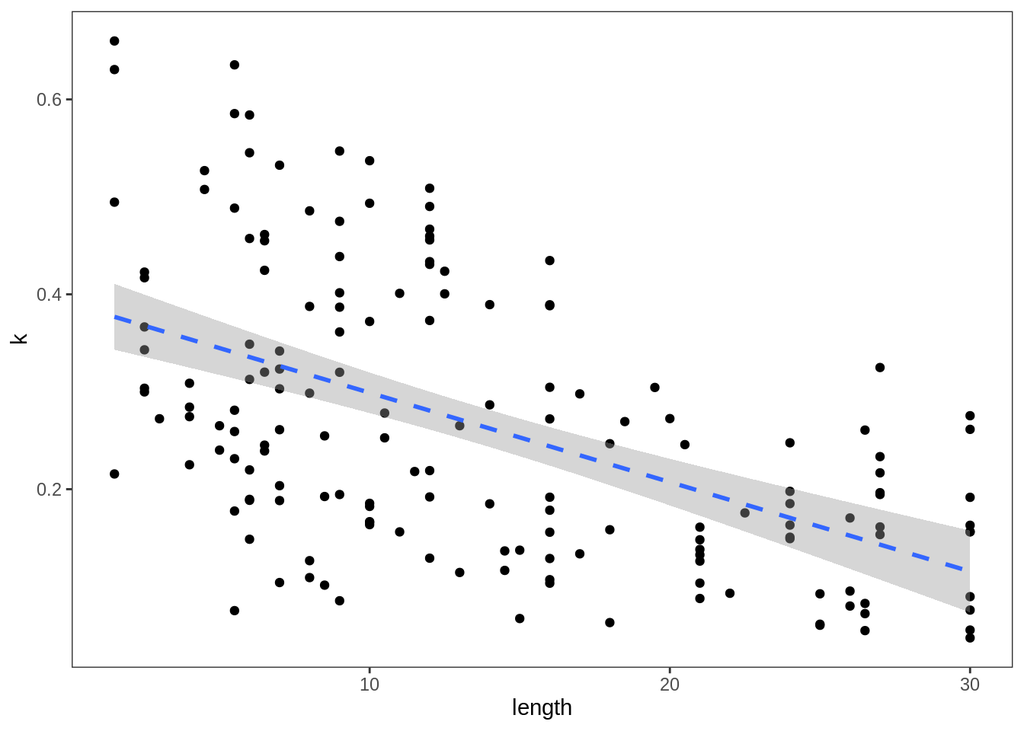

```r
growth_prepost <- growth_prepost %>%
  mutate(length=end_day-start_day)

growth_prepost %>%
  ggplot(aes(x=length, y=k)) +
  geom_point() +
  geom_smooth(method="lm", linetype=2) +
  theme_test()
```

Statistics:

- Pearson correlation

```r
cor.test(growth_prepost$k, growth_prepost$length, method="pearson")
```

```
##
##  Pearson's product-moment correlation
##
## data:  growth_prepost$k and growth_prepost$length
## t = -7.9006, df = 162, p-value = 4.006e-13
## alternative hypothesis: true correlation is not equal to 0
## 95 percent confidence interval:
##  -0.6297387 -0.4070326
## sample estimates:
##        cor
## -0.5273854
```

Length of growth vs change in abundance:

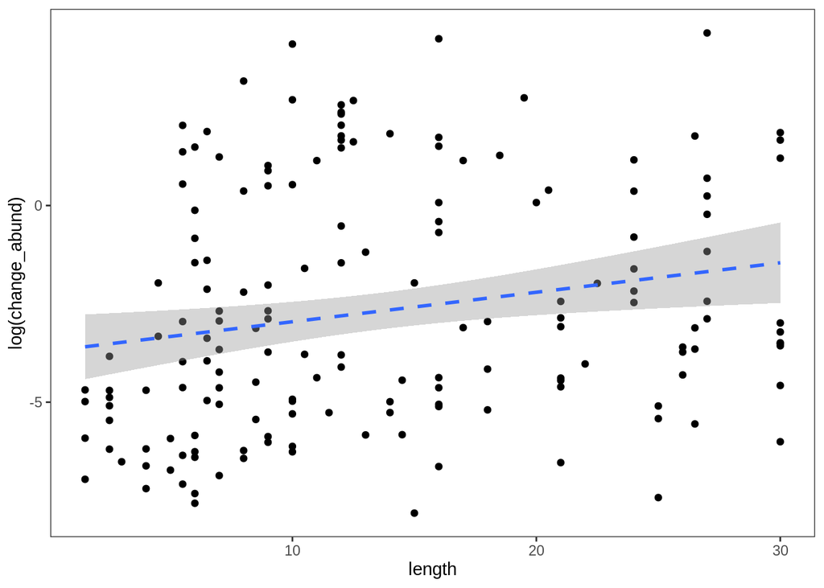

```r
growth_prepost %>%
  ggplot(aes(x=length, y=log(change_abund))) +
  geom_point() +
  geom_smooth(method="lm", linetype=2) +
  theme_test()
```

Statistics:

- Pearson correlation

```r
cor.test(log(growth_prepost$change_abund), growth_prepost$length, method="pearson")
```

```
##
##  Pearson's product-moment correlation
##
## data:  log(growth_prepost$change_abund) and growth_prepost$length
## t = 2.6534, df = 162, p-value = 0.008762
## alternative hypothesis: true correlation is not equal to 0
## 95 percent confidence interval:
##  0.05247533 0.34649691
## sample estimates:
##      cor
## 0.204084
```

Lag vs growth rate:

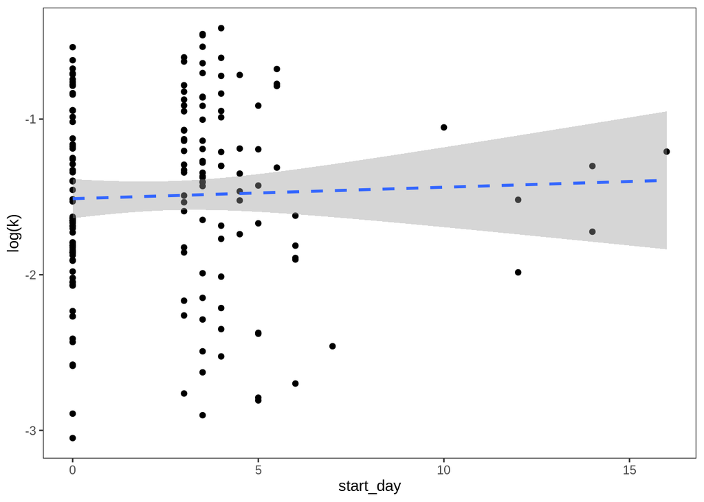

```r
growth_prepost %>%
  ggplot(aes(x=start_day, y=log(k))) +
  geom_point() +
  geom_smooth(method="lm", linetype=2) +
  theme_test()
```

Lag vs change in abundance:

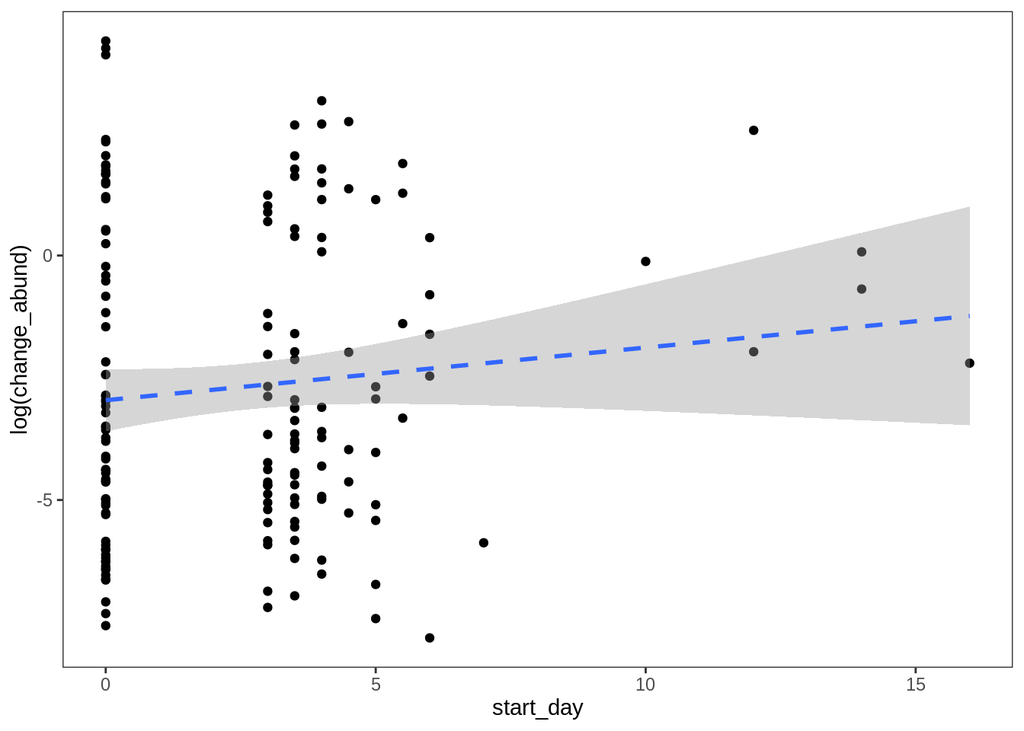

```r
growth_prepost %>%
  ggplot(aes(x=start_day, y=log(change_abund))) +
  geom_point() +
  geom_smooth(method="lm", linetype=2) +
  theme_test()
```

Statistics:

```r
cor.test(log(growth_prepost$change_abund), growth_prepost$start_day, method="spearm")
```

```
##
##  Spearman's rank correlation rho
##
## data:  log(growth_prepost$change_abund) and growth_prepost$start_day
## S = 663770, p-value = 0.2163
## alternative hypothesis: true rho is not equal to 0
## sample estimates:
##       rho
## 0.0970715
```

### Length of growth

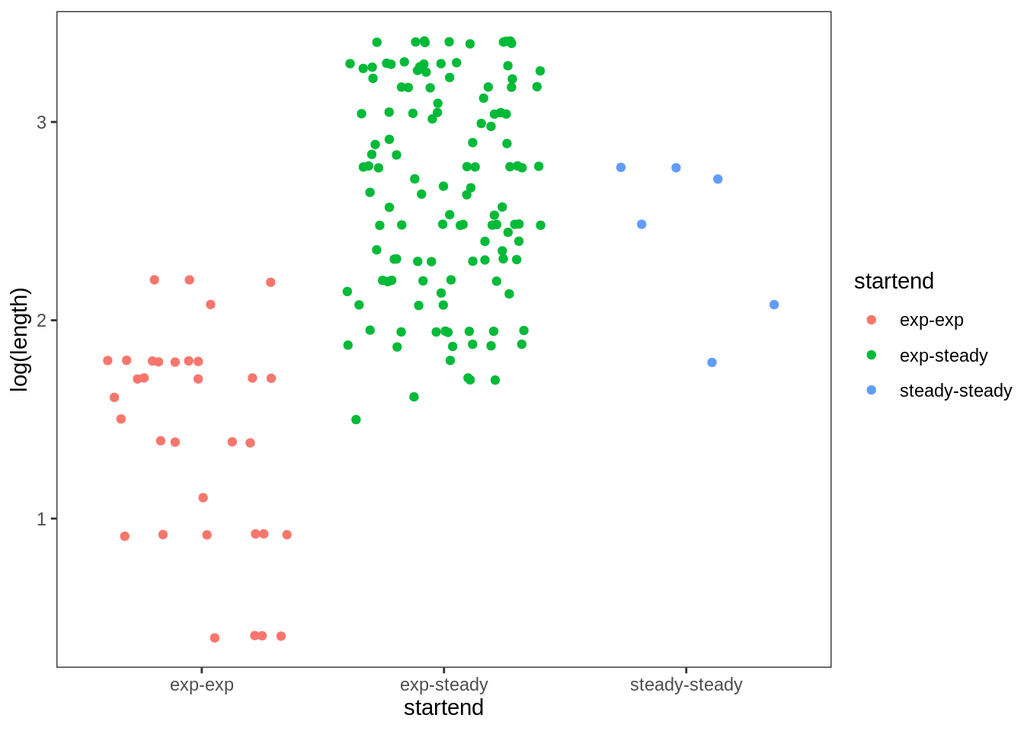

```r
growth_prepost %>%
  ggplot(aes(x=startend, y=log(length), color=startend)) +
  geom_jitter() +
  theme_test()
```

Statistics:

Linear mixed effects models with random slopes and intercepts for inoculant

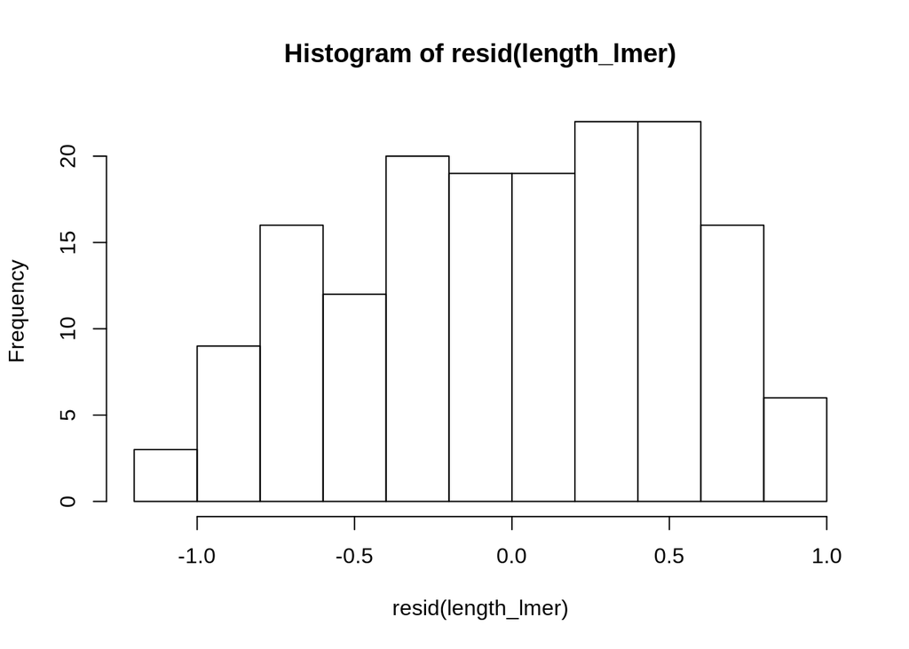

```r
length_lmer <- lmer(log(length) ~ startend + (1 + Inoculant | Inoculant), growth_prepost)
hist(resid(length_lmer))
```

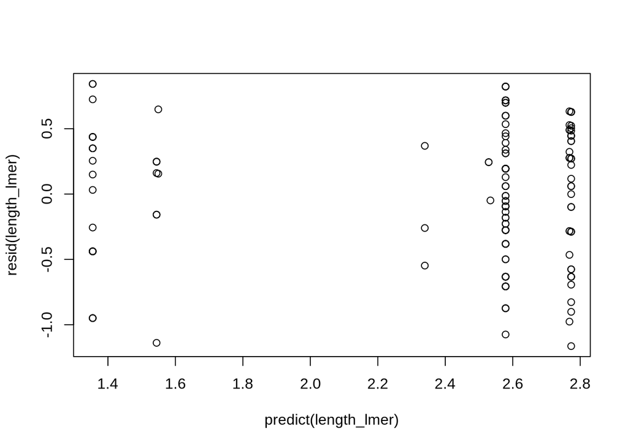

```r
plot(predict(length_lmer), resid(length_lmer))
```

```r
anova(length_lmer)
```

```
## Type III Analysis of Variance Table with Satterthwaite's method
##          Sum Sq Mean Sq NumDF DenDF F value    Pr(>F)
## startend 37.155  18.577     2 160.1  70.107 < 2.2e-16 ***
## ---
## Signif. codes:  0 '***' 0.001 '**' 0.01 '*' 0.05 '.' 0.1 ' ' 1
```

### 16S

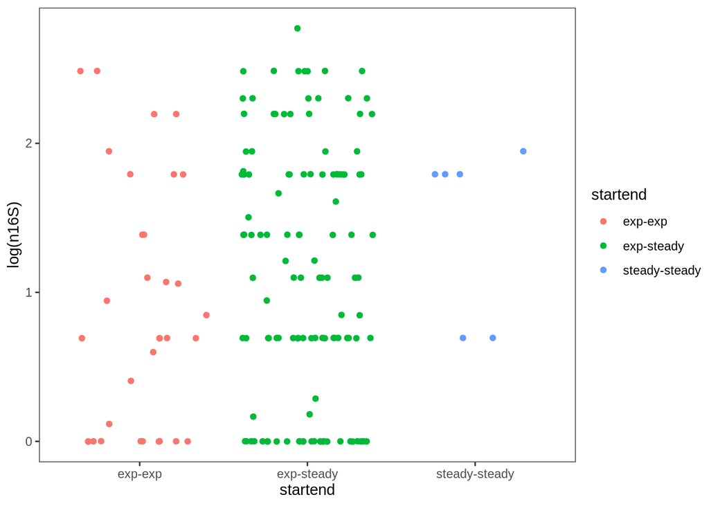

```r
growth_prepost %>%
  ggplot(aes(x=startend, y=log(n16S), color=startend)) +
  geom_jitter() +
  theme_test()
```

Statistics:

Linear mixed effects

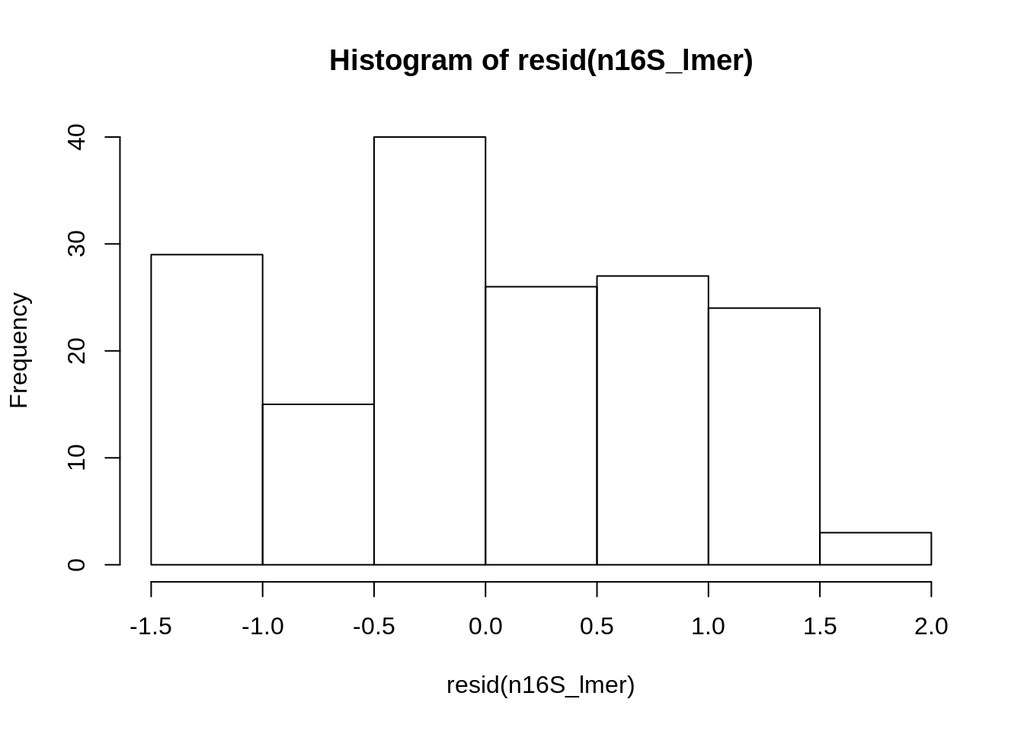

```r
n16S_lmer <- lmer(log(n16S) ~ startend + (1 + Inoculant | Inoculant), growth_prepost)
hist(resid(n16S_lmer))
```

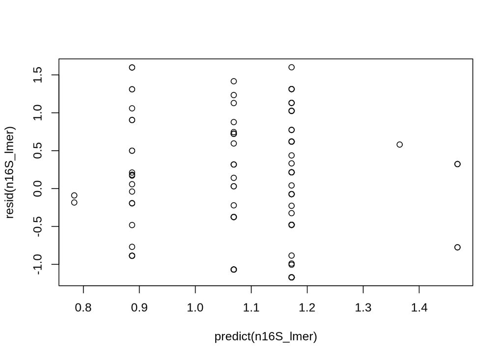

```r
plot(predict(n16S_lmer), resid(n16S_lmer))
```

```r
anova(n16S_lmer)
```

```
## Type III Analysis of Variance Table with Satterthwaite's method
##          Sum Sq Mean Sq NumDF  DenDF F value Pr(>F)
## startend  2.816   1.408     2 157.31  2.0578 0.1312
```

# Death

Death visualize:

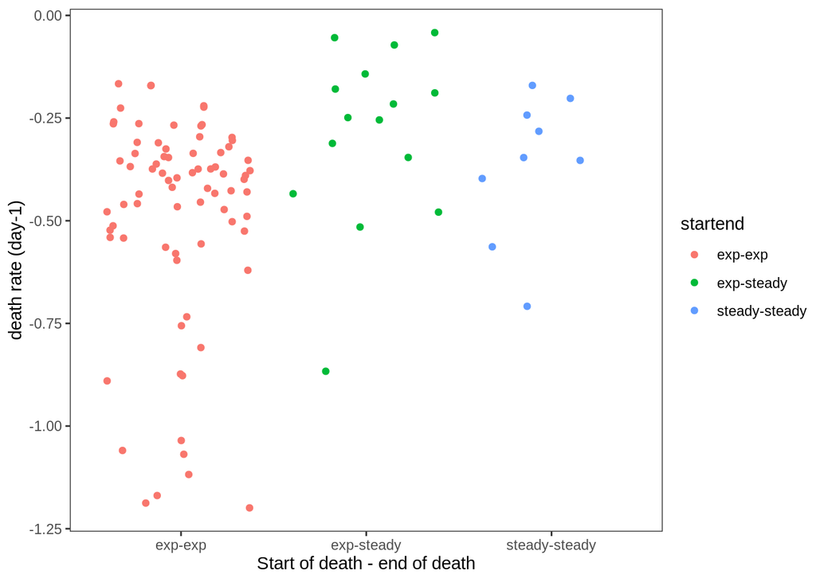

```r
# k
death_prepost %>%
  ggplot(aes(x=startend, y=k, color=startend)) +
  geom_jitter() +
  theme_test() +
  labs(y="death rate (day-1)", x="Start of death - end of death")
```

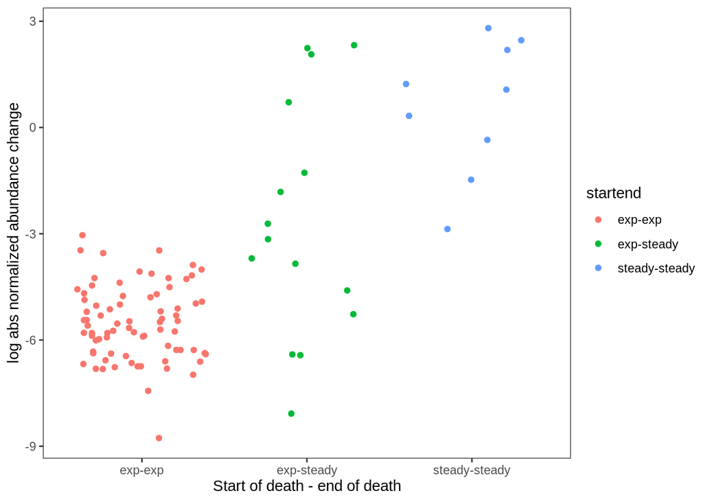

```r
# change in abundance
death_prepost %>%
  ggplot(aes(x=startend, y=log(abs(change_abund)), color=startend)) +
  geom_jitter() +
  theme_test() +
  labs(y="log abs normalized abundance change", x="Start of death - end of death")
```

### Death statistics

Linear mixed effects models with random slopes and intercepts for inoculant

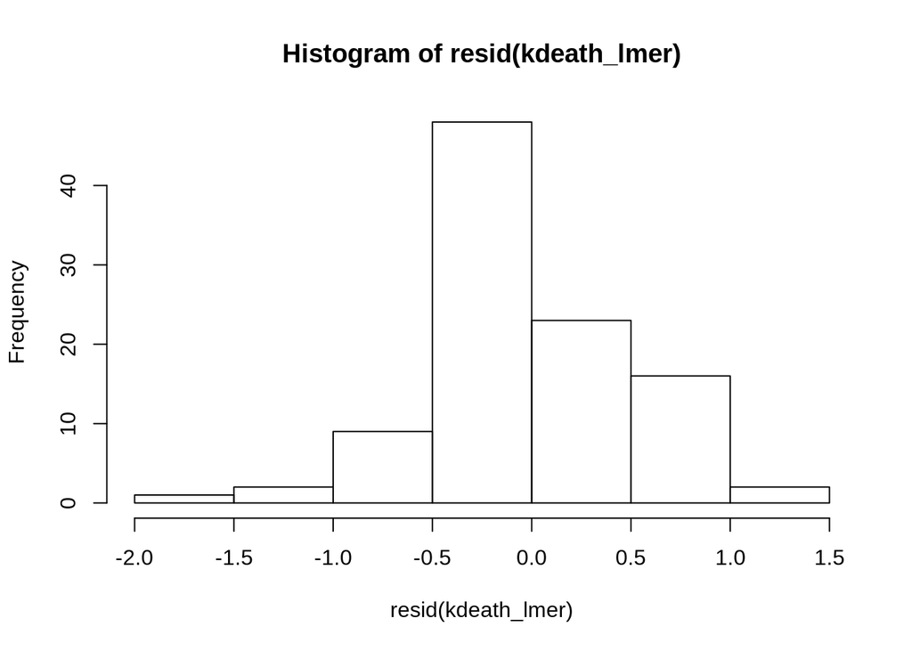

```r
# k
kdeath_lmer <- lmer(log(abs(k)) ~ startend + (1 + Inoculant | Inoculant), death_prepost)
hist(resid(kdeath_lmer))
```

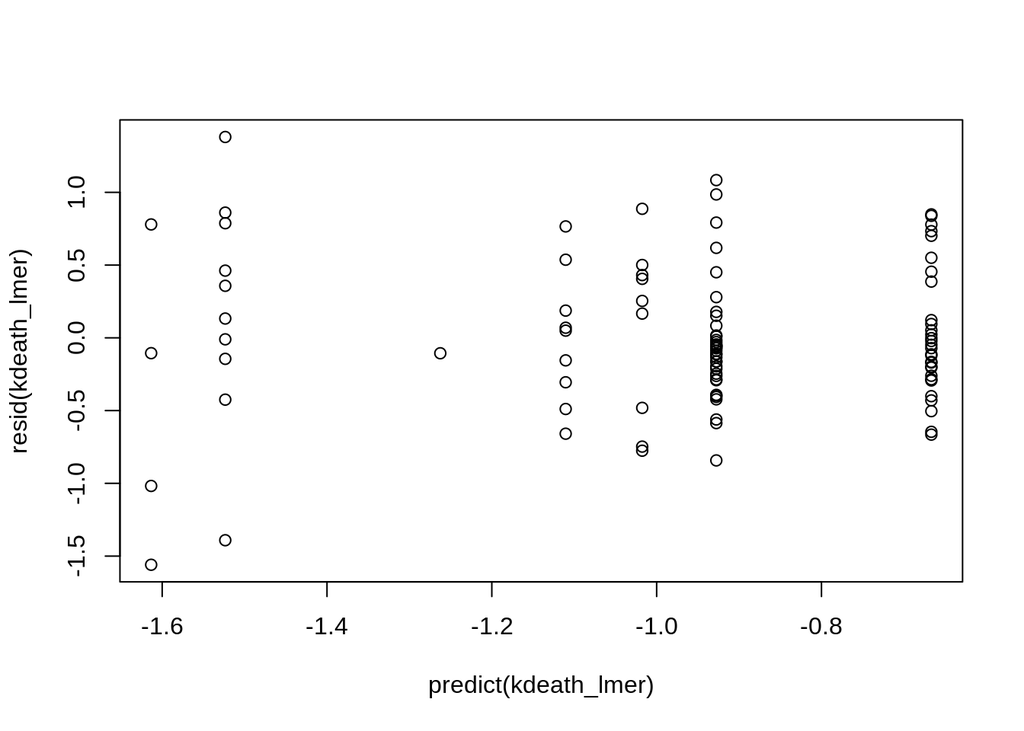

```r
plot(predict(kdeath_lmer), resid(kdeath_lmer))
```

```r
anova(kdeath_lmer)
```

```
## Type III Analysis of Variance Table with Satterthwaite's method
##          Sum Sq Mean Sq NumDF  DenDF F value    Pr(>F)
## startend   4.22    2.11     2 97.819  7.8274 0.0007026 ***
## ---
## Signif. codes:  0 '***' 0.001 '**' 0.01 '*' 0.05 '.' 0.1 ' ' 1
```

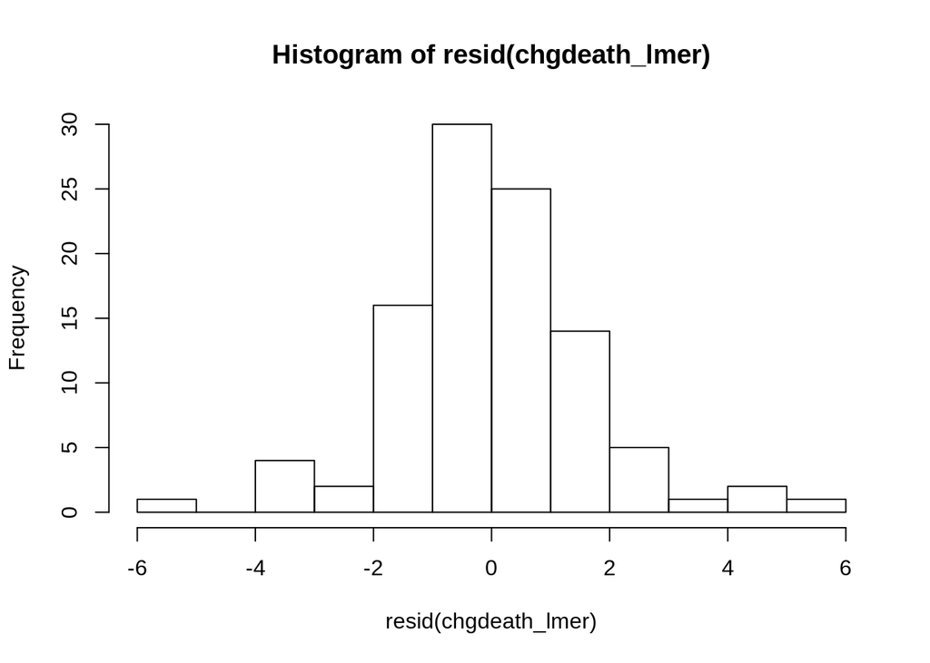

```r
# change abund
chgdeath_lmer <- lmer(log(abs(change_abund)) ~ startend + (1 + Inoculant | Inoculant), death_prepost)
hist(resid(chgdeath_lmer))
```

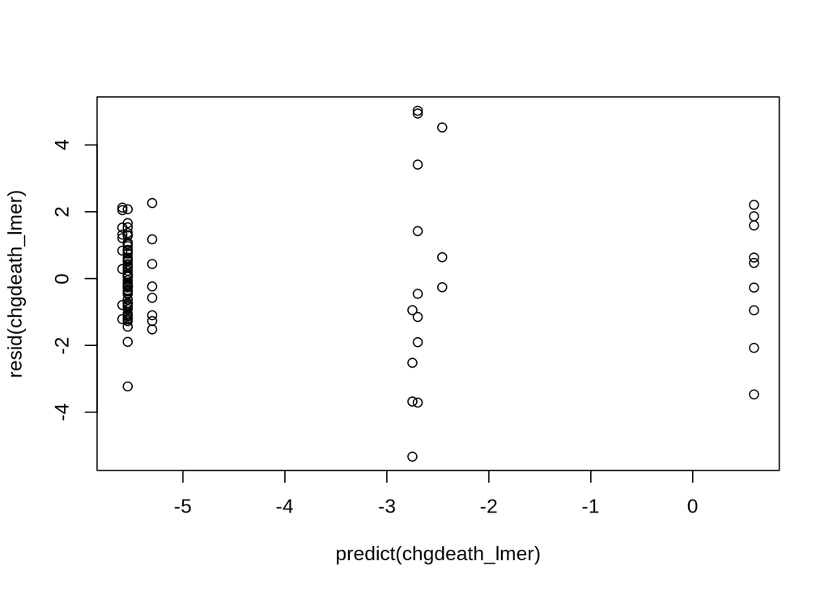

```r
plot(predict(chgdeath_lmer), resid(chgdeath_lmer))
```

```r
anova(chgdeath_lmer)
```

```
## Type III Analysis of Variance Table with Satterthwaite's method
##          Sum Sq Mean Sq NumDF  DenDF F value    Pr(>F)
## startend 365.63  182.81     2 95.991  67.266 < 2.2e-16 ***
## ---
## Signif. codes:  0 '***' 0.001 '**' 0.01 '*' 0.05 '.' 0.1 ' ' 1
```

# Community comparisons

### Alpha diversity

- at each tp, each inoc
- richness, shannon, evenness

```r
# Extract data from phyloseq
count_lvloff <- data.frame(otu_table(physeq_lvloff)) %>%
  rownames_to_column(var="ASV") %>%
  gather(SampleID, count, -ASV)

tax_lvloff <- data.frame(tax_table(physeq_lvloff))

# Combine
count_tax_meta <- inner_join(count_lvloff, tax_lvloff) %>%
  inner_join(meta_lvloff, by="SampleID") %>%
  mutate(Inoculant = as_factor(Inoculant)) %>%
  mutate(across(Domain:Species, ~as.character(.x), {.col})) %>%
  filter(ASV != "445e8681c3c1a735760e6c394f5f4d0a") # remove spike-in
```

Calculate richness, Shannon’s, evenness (J):

J = H/log(S)

Where H is Shannon-Weaver index and S is richness.

```r
# Reformat counts to be compatible with vegan
count_tax_meta_wide <- count_tax_meta %>%
  select(ASV, SampleID, count) %>%
  pivot_wider(names_from="ASV", values_from="count") %>%
  column_to_rownames(var="SampleID")

# Calculate
shannon <- diversity(count_tax_meta_wide, "shannon")
richness <- specnumber(count_tax_meta_wide)
evenness <- shannon/log(richness)

# Add evennness values to data
even_df <- data.frame(evenness) %>%
  rownames_to_column(var="SampleID")

alpha_df <- data.frame(richness) %>%
  rownames_to_column(var="SampleID") %>%
  inner_join(even_df)

# Add Shannon's diversity index
alpha_df <- data.frame(shannon) %>%
  rownames_to_column(var="SampleID") %>%
  inner_join(alpha_df)

# Add metadata
alpha_df <- inner_join(alpha_df, meta_lvloff) %>%
  mutate(leveloff = as_factor(leveloff),
         leveloff = fct_relevel(leveloff, levels=c("pre", "post")))

# Sumarize pre and post level off
alpha_prepost <- alpha_df %>%
  group_by(Inoculant, leveloff) %>%
  summarize(richness = mean(richness, na.rm=TRUE),
            evenness = mean(evenness, na.rm=TRUE),
            shannon = mean(shannon, na.rm=TRUE))

# Summarize across replicates each day
alpha_day <- alpha_df %>%
  group_by(Inoculant, Day, leveloff) %>%
  summarize(richness = mean(richness, na.rm=TRUE),
            evenness = mean(evenness, na.rm=TRUE),
            shannon = mean(shannon, na.rm=TRUE))
```

Visualize:

Summary

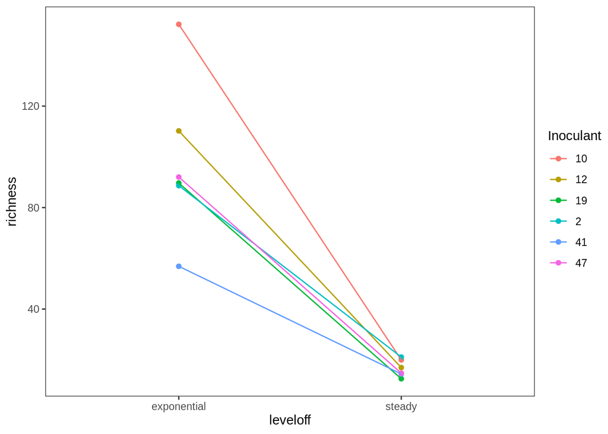

```r
# richness
alpha_prepost %>%
  ggplot(aes(x=leveloff, y=richness, color=Inoculant)) +
  geom_point() +
  geom_line(aes(group=Inoculant)) +
  theme_test()
```

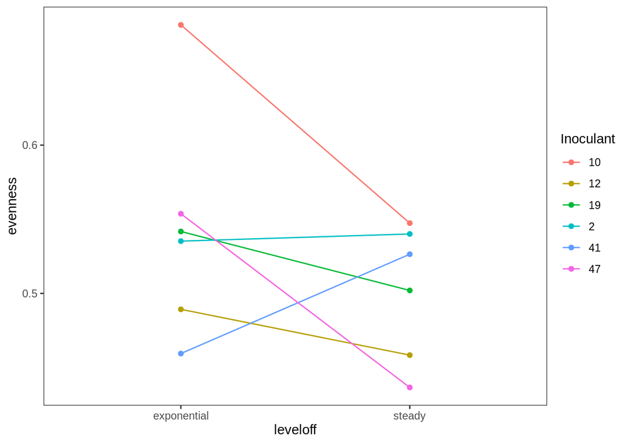

```r
# Evenness
alpha_prepost %>%
  ggplot(aes(x=leveloff, y=evenness, color=Inoculant)) +
  geom_point() +
  geom_line(aes(group=Inoculant)) +
  theme_test()
```